Brandwise Batch Analysis - Order to Ship/Post Author: Matt Palmer 1.9.22 - 2.1.22

# Objective

Examine the approximate time frame and summary statistics from order creation to posting for Brandwise batches printed (1.9.22 – 1.19.22) and shipped between (1.11.22 - 2.1.22).

- **Sample size** = 156 observations
- **Number of observations excluded from batch data** = 53

#### Configuration and Libraries

```r
library(tidyverse)
library(dplyr)
library(readxl)
library(Hmisc)
```

#### Load Brandwise Batches 1/9/22 - 1/19/22

```r
orders <- read.csv('BrandWise_Batches_2201.csv', header = TRUE, sep = "," )
#Drop 'X' and 'Credit Sheet' Columns

print(colnames(orders))
```

```
##  [1] "P.O."         "BatchID"      "Batch.Date"   "Print.Date"   "Order.Date"
##  [6] "Customer"     "X"            "Total.Items"  "Credit.Sheet" "Order.Total"
```

```r
orders <- subset(orders, select = -c(7, 9))
head(orders)
```

```
##          P.O. BatchID   Batch.Date   Print.Date Order.Date
## 1 1.35021E+13 3960122 1/9/22 21:05 1/9/22 21:05   7-Jan-22
## 2   1023-2464 3960122 1/9/22 21:05 1/9/22 21:05   7-Jan-22
## 3   1014-2514 3960122 1/9/22 21:05 1/9/22 21:05   5-Jan-22
## 4   1059-2553 3960122 1/9/22 21:05 1/9/22 21:05   5-Jan-22
## 5   1039-2024 3960122 1/9/22 21:05 1/9/22 21:05   4-Jan-22
## 6   1110-1073 3960122 1/9/22 21:05 1/9/22 21:05   8-Jan-22
##                                                                        Customer
## 1           OMNI HOTEL - GPI MARKETPLACE, 290 MACON AVENUE, ASHEVILLE, NC 28804
## 2                     COCO & TOULOUSE, 7015 SE MILWAUKIE AV, PORTLAND, OR 97202
## 3                  FOREVER NEW ORLEANS, 700 ROYAL STREET, NEW ORLEANS, LA 70116
## 4 FLOWER MOUND HOSPITAL AUXILIARY, 4400 LONG PRAIRIE RD, FLOWER MOUND, TX 75028
## 5                           EL-KAN DRUG, 1033 N. KANSAS AVE., LIBERAL, KS 67901
## 6      THRIFTY WAY PHARMACY OF ABBEVILLE, 2640 NORTH DRIVE, ABBEVILLE, LA 70510
##   Total.Items Order.Total
## 1          32    $216.00
## 2          56    $432.00
## 3          72    $488.00
## 4          48    $324.00
## 5         104    $752.00
## 6          48    $340.00
```

#### Summary of Data

```r
describe(orders) %>% html()
```

orders  
8 Variables 209 Observations

P.O.

| n | missing | distinct |
| --- | --- | --- |
| 209 | 0 | 200 |

| lowest : | 1.35021E+13 | 100-235923 | 100-235925 | 100-235927 | 100-235929 |
| --- | --- | --- | --- | --- | --- |
| highest: | GS2022-36 | MCFARLAND-PUFFIN | PELLCITY-PUFFIN | PUF011122 | WSHG11621 |

BatchID

| n | missing | distinct | Info | Mean | Gmd |
| --- | --- | --- | --- | --- | --- |
| 209 | 0 | 6 | 0.946 | 3965266 | 4315 |

lowest : 3960122 3961688 3964388 3965438 3968651 , highest: 3961688 3964388 3965438 3968651 3970570

```
 Value      3960122 3961688 3964388 3965438 3968651 3970570
 Frequency       53      18      24      23      67      24
 Proportion   0.254   0.086   0.115   0.110   0.321   0.115
```

Batch.Date

| n | missing | distinct |
| --- | --- | --- |
| 209 | 0 | 6 |

| lowest : | 1/13/22 11:07 | 1/11/22 9:28 | 1/14/22 9:10 | 1/18/22 11:34 | 1/19/22 18:59 |
| --- | --- | --- | --- | --- | --- |
| highest: | 1/11/22 9:28 | 1/14/22 9:10 | 1/18/22 11:34 | 1/19/22 18:59 | 1/9/22 21:05 |

```
 Value      1/13/22 11:07  1/11/22 9:28  1/14/22 9:10 1/18/22 11:34 1/19/22 18:59
 Frequency             24            18            23            67            24
 Proportion         0.115         0.086         0.110         0.321         0.115

 Value       1/9/22 21:05
 Frequency             53
 Proportion         0.254
```

Print.Date

| n | missing | distinct |
| --- | --- | --- |
| 209 | 0 | 6 |

| lowest : | 1/19/22 6:59 | 1/11/22 9:29 | 1/13/22 11:07 | 1/14/22 9:10 | 1/18/22 11:34 |
| --- | --- | --- | --- | --- | --- |
| highest: | 1/11/22 9:29 | 1/13/22 11:07 | 1/14/22 9:10 | 1/18/22 11:34 | 1/9/22 21:05 |

```
 Value       1/19/22 6:59  1/11/22 9:29 1/13/22 11:07  1/14/22 9:10 1/18/22 11:34
 Frequency             24            18            24            23            67
 Proportion         0.115         0.086         0.115         0.110         0.321

 Value       1/9/22 21:05
 Frequency             53
 Proportion         0.254
```

Order.Date

| n | missing | distinct |
| --- | --- | --- |
| 209 | 0 | 16 |

| lowest : | 10-Jan-22 | 11-Jan-22 | 12-Jan-22 | 13-Jan-22 | 14-Jan-22 |
| --- | --- | --- | --- | --- | --- |
| highest: | 5-Jan-22 | 6-Jan-22 | 7-Jan-22 | 8-Jan-22 | 9-Jan-22 |

```
 Value      10-Jan-22 11-Jan-22 12-Jan-22 13-Jan-22 14-Jan-22 15-Jan-22 16-Jan-22
 Frequency         13        13        28        33        26        19         4
 Proportion     0.062     0.062     0.134     0.158     0.124     0.091     0.019

 Value      17-Jan-22 18-Jan-22 19-Jan-22  4-Jan-22  5-Jan-22  6-Jan-22  7-Jan-22
 Frequency          2         6         1         7         8        11        20
 Proportion     0.010     0.029     0.005     0.033     0.038     0.053     0.096

 Value       8-Jan-22  9-Jan-22
 Frequency         13         5
 Proportion     0.062     0.024
```

Customer

| n | missing | distinct |
| --- | --- | --- |
| 209 | 0 | 185 |

| lowest : | 5518 DESIGNS, 27 N. MAIN STREET, BUTTE, MT 59701 | ACE BARNES HARDWARE, 2105 WEST STADIUM BLVD, ANN ARBOR, MI 48103 | AGGIE'S GIFT SHOP, 979 WASHINGTON STREET WEST, LEWISBURG, WV 24901 | ALASKA-JUNEAU MINING COMPANY, 425 S. FRANKLIN ST., JUNEAU, AK 99801-1327 | Allisonville Home & Garden, 11405 Allisonville Rd, Fishers, IN 46038 |
| --- | --- | --- | --- | --- | --- |
| highest: | White farmhouse flowers, 12155 Nw 81st Street, Kansas City, MO 64152 | WILLOW HOUSE, 238 W. PECAN, CELINA, TX 75009 | WOODY'S, 4 WOODROW RD., HANOVER, NH 03755 | WORK THE METAL, 1201B STORY AVE, LOUISVILLE, KY 40206 | YE PEDDLER GIFT SHOPPE, 305 W. 8TH ST., COLUMBIA, TN 38401 |

Total.Items

| n | missing | distinct | Info | Mean | Gmd | .05 | .10 | .25 | .50 | .75 | .90 | .95 |
| --- | --- | --- | --- | --- | --- | --- | --- | --- | --- | --- | --- | --- |
| 209 | 0 | 42 | 0.994 | 94.28 | 84.72 | 24 | 32 | 40 | 72 | 89 | 160 | 288 |

lowest : 1 16 24 32 40 , highest: 424 456 736 840 913

Order.Total

| n | missing | distinct |
| --- | --- | --- |
| 209 | 0 | 112 |

| lowest : | $0.00 | $1,016.00 | $1,036.00 | $1,108.00 | $1,176.00 |
| --- | --- | --- | --- | --- | --- |
| highest: | $832.00 | $836.00 | $860.00 | $880.00 | $996.00 |

## Data Wrangling

#### Convert Columns to DT

```r
orders$Batch.Date <- as.POSIXct(orders$Batch.Date,
                                format = "%m/%d/%y %H:%M")
orders$Print.Date <- as.POSIXct(orders$Print.Date,
                                format = "%m/%d/%y %H:%M")
orders$Order.Date <- as.POSIXct(orders$Order.Date,
                                format = "%d-%b-%y")
```

#### Convert Totals to Type = Double

```r
orders$Order.Total <- as.numeric(gsub("[\\$,]", "", orders$Order.Total))
```

#### Load Sales Order Data

```r
so_data <- read_excel("Sales Orders 22_0104-0119.xlsx")
```

#### Load Posted Sales Inovice Data

```r
posted <- read_excel("Posted Sales Invoices_1.1.22-2.3.22.xlsx")
```

#### Merge DataFrames

```r
df <- merge(orders, posted, by.x = c("P.O."), by.y = c("External Document No."), all.y = FALSE)
df <- subset(select(df, -c("Currency Code")))
head(df)
```

```
##         P.O. BatchID          Batch.Date          Print.Date Order.Date
## 1 100-235923 3970570 2022-01-19 18:59:00 2022-01-19 06:59:00 2022-01-15
## 2 100-235925 3970570 2022-01-19 18:59:00 2022-01-19 06:59:00 2022-01-15
## 3 100-235927 3970570 2022-01-19 18:59:00 2022-01-19 06:59:00 2022-01-15
## 4 100-235929 3970570 2022-01-19 18:59:00 2022-01-19 06:59:00 2022-01-15
## 5 100-235931 3970570 2022-01-19 18:59:00 2022-01-19 06:59:00 2022-01-15
## 6 100-235933 3970570 2022-01-19 18:59:00 2022-01-19 06:59:00 2022-01-15
##                                                    Customer Total.Items
## 1 LOGAN ACE HARDWARE, 1734 14TH ST NW, WASHINGTON, DC 20009          89
## 2 LOGAN ACE HARDWARE, 1734 14TH ST NW, WASHINGTON, DC 20009          89
## 3 LOGAN ACE HARDWARE, 1734 14TH ST NW, WASHINGTON, DC 20009          89
## 4 LOGAN ACE HARDWARE, 1734 14TH ST NW, WASHINGTON, DC 20009          89
## 5 LOGAN ACE HARDWARE, 1734 14TH ST NW, WASHINGTON, DC 20009          89
## 6 LOGAN ACE HARDWARE, 1734 14TH ST NW, WASHINGTON, DC 20009          89
##   Order.Total       No. Posting Date Order No. Customer No.      Customer Name
```

[output cut: 27 more lines]

#### Drop Missing Values

```r
rows_with_na <- df[rowSums(is.na(df)) > 0,]
```

```r
df <- df %>% drop_na() # drop rows with missing data
```

#### Calculate Order-to-Ship (OTS), Ship-to-Post (STP), Order-to-Post

```r
df$Order_to_Ship <- difftime(df$`Shipment Date`, df$Order.Date, units = 'days') %>% as.numeric()
df$Ship_to_Post <- difftime(df$`Posting Date`, df$'Shipment Date', units = 'days') %>% as.numeric()
df$Order_to_Post <- difftime(df$`Posting Date`, df$Order.Date, units = 'days') %>% as.numeric()

print(head(df[c("Order.Date", "Shipment Date", "Posting Date", "Order_to_Ship", "Ship_to_Post", "Order_to_Post")]))
```

```
##   Order.Date Shipment Date Posting Date Order_to_Ship Ship_to_Post
## 1 2022-01-15    2022-01-25   2022-01-29      9.666667            4
## 2 2022-01-15    2022-01-25   2022-01-29      9.666667            4
## 3 2022-01-15    2022-01-25   2022-01-29      9.666667            4
## 4 2022-01-15    2022-01-25   2022-01-29      9.666667            4
## 5 2022-01-15    2022-01-25   2022-01-29      9.666667            4
## 6 2022-01-15    2022-01-25   2022-01-29      9.666667            4
##   Order_to_Post
## 1      13.66667
## 2      13.66667
## 3      13.66667
## 4      13.66667
## 5      13.66667
## 6      13.66667
```

## Analysis

#### Summary Statistics

**Order to Ship**

```r
summary(df$Order_to_Ship)
```

```
##    Min. 1st Qu.  Median    Mean 3rd Qu.    Max.
##   2.667   5.667   7.667   7.865   8.667  24.667
```

**Ship to Post**

```r
summary(df$Ship_to_Post)
```

```
##    Min. 1st Qu.  Median    Mean 3rd Qu.    Max.
##   0.000   4.000   7.000   8.224  12.250  21.000
```

**Order to Post**

```r
summary(df$Order_to_Post)
```

```
##    Min. 1st Qu.  Median    Mean 3rd Qu.    Max.
##   2.667  13.667  15.667  16.090  19.667  26.667
```

#### Histograms

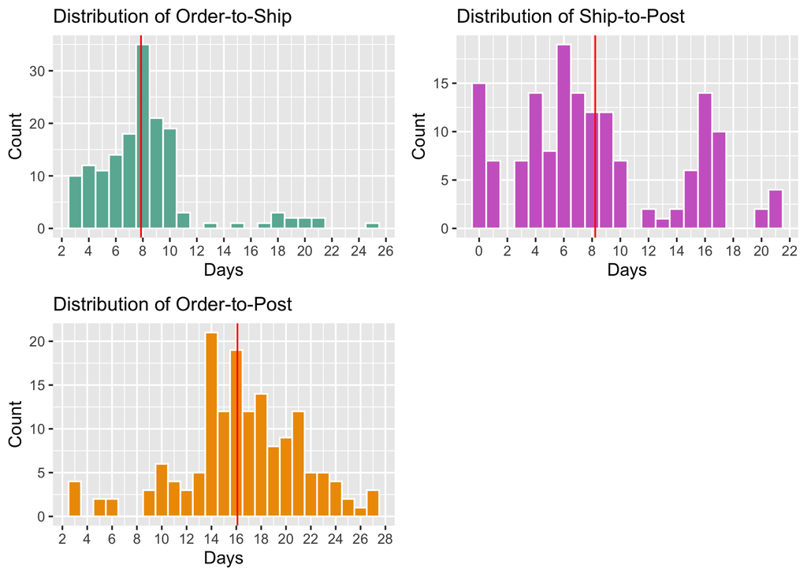

```r
library(ggplot2)
library(hrbrthemes)

x_bar_ots <- mean(df$Order_to_Ship)
x_bar_stp <- mean(df$Ship_to_Post)
x_bar_otp <- mean(df$Order_to_Post)

ots_hist <- ggplot(data = df, aes(Order_to_Ship)) +
  geom_histogram(binwidth = 1, color = 'white', fill = '#69b3a2') +
  geom_vline(xintercept = x_bar_ots, show.legend = TRUE, color = 'red') +
  ggtitle("Distribution of Order-to-Ship") +
  labs(x = 'Days', y = 'Count') +
  scale_x_continuous(breaks=seq(0, 30, 2)) +
  theme(
    plot.title = element_text(size=12)
    )

stp_hist <- ggplot(data = df, aes(Ship_to_Post)) +
  geom_histogram(binwidth = 1, color = 'white', fill = 'orchid3') +
  geom_vline(xintercept = x_bar_stp, show.legend = TRUE, color = 'red') +
  ggtitle("Distribution of Ship-to-Post") +
  labs(x = 'Days', y = 'Count') +
  scale_x_continuous(breaks=seq(0, 30, 2)) +
  theme(
    plot.title = element_text(size=12)
    )

otp_hist <- ggplot(data = df, aes(Order_to_Post)) +
  geom_histogram(binwidth = 1, color = 'white', fill = 'orange2') +
  geom_vline(xintercept = x_bar_otp, show.legend = TRUE, color = 'red') +
  ggtitle("Distribution of Order-to-Post") +
  labs(x = 'Days', y = 'Count') +
  scale_x_continuous(breaks=seq(0, 30, 2)) +
  theme(
    plot.title = element_text(size=12)
    )

require(gridExtra)

grid.arrange(ots_hist, stp_hist, otp_hist, ncol=2)
```

Based on the histograms, we see slightly positive (right skewed) distributions for all three metrics OTS, STP, OTP. The vertical red line shows the arithmetic mean (average) for the distribution. An interesting note is that it takes about as long on average to post an invoice as it does to ship an order.

#### Scatter Plot

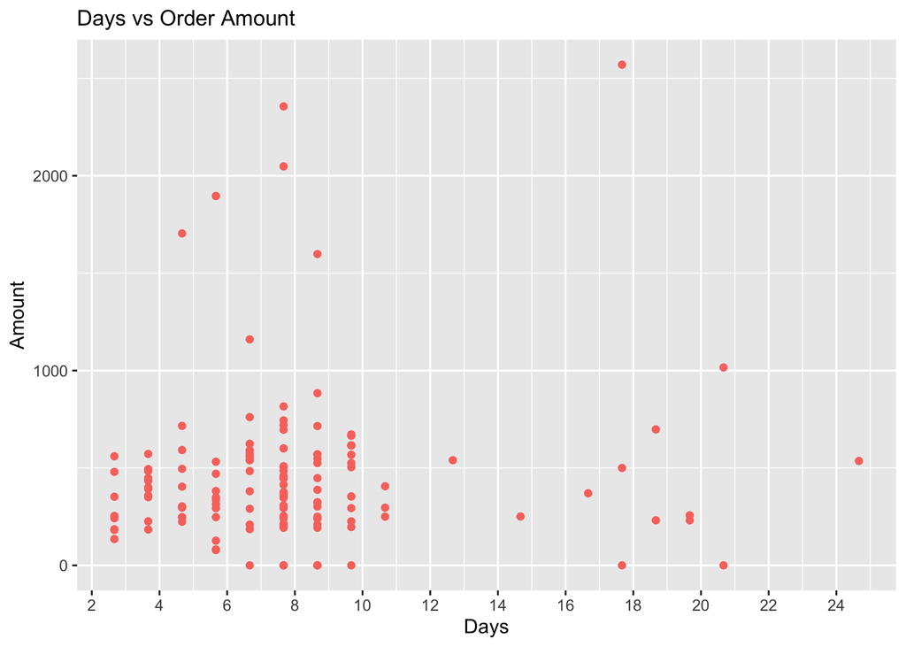

```r
ggplot(df, aes(x=Order_to_Ship, y=Amount)) + geom_point(aes(color = 'red')) +
  ggtitle("Days vs Order Amount") +
  labs(x = 'Days', y = 'Amount') +
  theme(legend.position = 'none') +
  scale_x_continuous(breaks=seq(0, 30, 2)) +
  theme(
    plot.title = element_text(size=12)
    )
```

The scatter plot comparing Order-to-Ship vs Order Amount shows no real pattern based on order size. Large orders take approximately the same amount of time to ship as small orders.

#### Box Plots

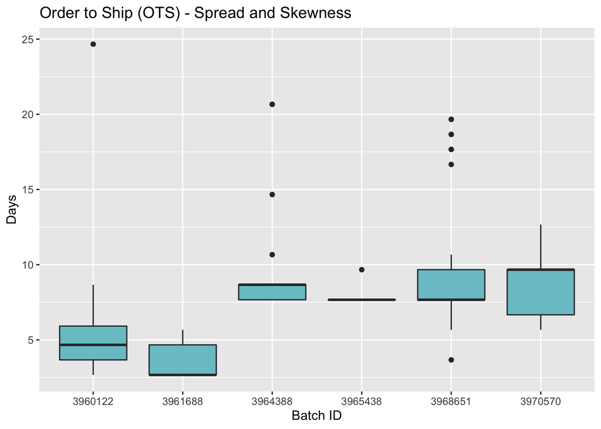

```r
ggplot(df, aes(x=factor(BatchID), y=Order_to_Ship)) +
  geom_boxplot(fill = "cadetblue3") +
  ggtitle("Order to Ship (OTS) - Spread and Skewness") +
  labs(x = 'Batch ID', y = 'Days')+
  scale_y_continuous(breaks=seq(0, 30, 5))
```

Box plots help us examine the interquartile range and median values for Order-to-Ship (OTS) over the sample time period. The first set of box plots show relatively stable variance, trending upwards slightly as we moved further away from the holidays. One interesting note, the first batch 3960122 took several days from order to batch so it’s a bit surprising to see such fast ship times for this group.

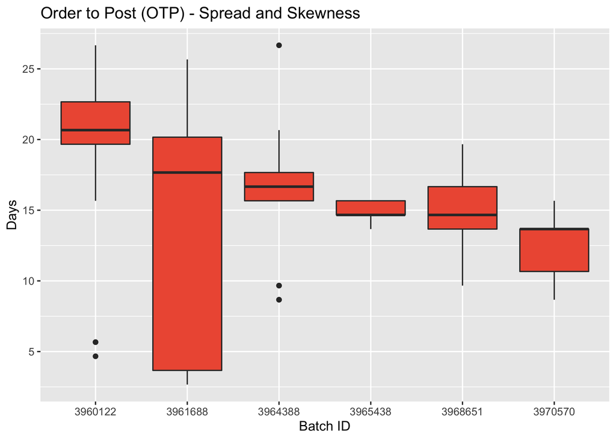

```r
ggplot(df, aes(x=factor(BatchID), y=Order_to_Post)) +
  geom_boxplot(fill = "tomato2") +
  ggtitle("Order to Post (OTP) - Spread and Skewness") +
  labs(x = 'Batch ID', y = 'Days') +
  scale_y_continuous(breaks=seq(0, 30, 5))
```

# Conclusion

# Recomendations

1. Examine the process from shipment to posted invoice and find ways to reduce this interval.
2. Try to identify the underlying cause for the orders that took longer than 15 days to ship.